# Theory Assignment - Sampling Distributions Unveiled

## Sampling Distributions

**Define the term “sampling distribution.”**

Sampling Distribution is when we start from the population, decide our sample size (*n*, lowercase) by by which we can make a distribution, then decide the number of repetitions to take that sample size and make distributions. (*N*, uppercase) times and create a distribution of those N distributions.

**Demonstrate how the sampling distribution is obtained for both the slope and the intercept estimates in regression.**

Create data (as shown in the code block), run regressions on them, then index the slopes and y-intercepts to store them for use creating histograms. Finally, create histograms of the slopes and y-intercepts.

**Clearly explain what the mean and standard deviation (often called the standard error) are for each of these two distributions.**

When histograms are made of all those stored y-ints and slopes, the middle of it is the mean. This is not to be confused with the standard deviation. Standard deviation is the spread of the data, the standard error is the spread of the y-intercept/slope histograms.

**Most importantly, provide thorough explanation of what the standard error measures.**

The standard error is 1 standard deviation of the slope. This means is measures how likely the y-intercept/slope varies from the population mean (true mean).

## P-values

**Demonstrate how the standard errors of the sampling distributions for both the slope and intercept estimates are used to obtain p-values for the tests of hypotheses about β0and β1(the true intercept and slope of the regression model).**

In the normal lm() function we use for linear regression, the null and alternative hypotheses are set to 0. We can change this by calculating the t-value. This is done by

$$\frac{ \text{(slope estimate - null hypothesis)} } {\text{slope of standard error} }$$

**Discuss why this works.**

This is the same behind the scene math that the lm() function uses, but the null hypothesis is set to 0.

**Reveal the logic behind the p-value.**

## Confidence Intervals

**Demonstrate how the standard errors are also used to create confidence intervals for the true regression intercept, β0, and true regression slope, β1.**

The standard error is used to obtain a t-value (along with the null hypothesis and standard error).

The t-value is used to obtain a p-value. It’s done my taking the t-distribution (think 221 applet from class), warp it based on the degrees of freedom, then calculate the t-value based on that.

**Explain what a confidence interval really is… explain why it captures the true parameter values “95% of the time.”**

For this section we’ll use a 95% confidence interval. The estimate of concern will be the slope. This confidence interval percentage can be changed as desired and the slope is interchangeable with the y-intercept.

A confidence interval is a lower an upper bound containing the slope. It is based on the given slope value and the upper and lower bounds are made by the formula:

$$b_1 \pm t^*_{n-2}\cdot s_{b_1}$$

This formula is the test statistic at n-2 degrees of freedom multiplied by the standard error of the sample.

It is confident that it contains the slope 95% of the time.

#### Appendix

Click on the code button to see the logic logic behind the creation of the plots below. These plots are used in the following analysis for instruction. Please refer to them as needed.

```r
# Important Simulation Fun

N <- 500 # reps of how many times you'll grab your samples
yint <- rep(NA, N) # create "N" empty boxes and fill them with "NA"'s. We'll append to the data into them later
slope <- rep(NA, N) # create empty boxes to append the data to later

for (i in 1:N){
  n <- 40
  Xi <- rep(seq(30, 100, length.out=n/2), each=2) #n must be even. 20 x's!
      # create x values from this to this and make the n/2 of them. It'll do the division of what the steps need to be automatically
      # this is playing with the denominator of the variance formula (summation of individual x values - mean of x's all squared)
      # making the x values

  Yi <- 2.5 + 3*Xi + rnorm(n, 0, 11.2) # the law, 40 y's!!!
    # making the y values
    # y-int + slope * X + error term
  # We make the law (yint and slope), then feed in the randomized x values we coded up
    # rnorm is the error term.
    # rnorm(n, mean, constant variance)
    # this is sigma squared (numerator of standard error)

  mylm <- lm(Yi ~ Xi)

  yint[i] <- coef(mylm)[1] #intercept only
  slope[i] <- coef(mylm)[2] #slope only
}
```

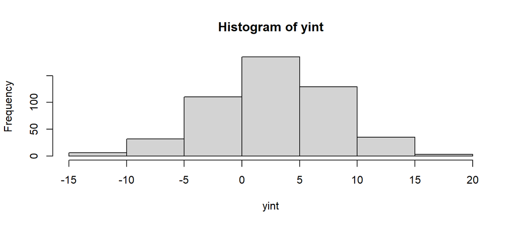

```r
hist(yint) # histogram of all the y-intercepts made from the "N" repetitions of the n sample size and the data created by the Xi and Yi values.
```

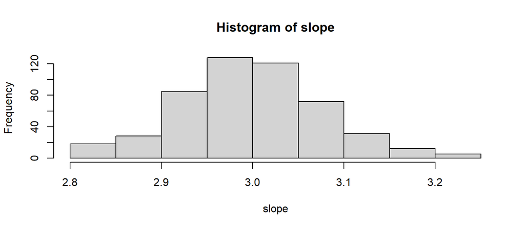

```r
hist(slope)
```

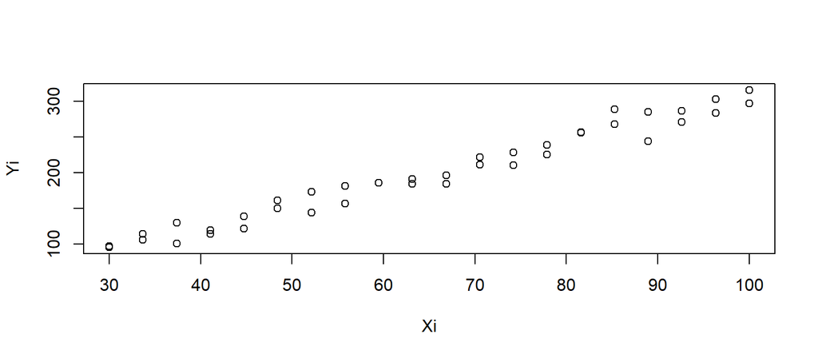

```r
plot(Yi ~ Xi)
```